# Test a Perceptual Phenomenon

### Analyzing the Stroop Effect

(1) What is the independent variable? What is the dependent variable?

- independent variable: a congruent words condition, and an incongruent words condition.
- dependent variable: time

(2) What is an appropriate set of hypotheses for this task? What kind of statistical test do you expect to perform? Justify your choices.

We denote that average time taken from congruent words condition is t1, average time taken from incongruent words condition is t2.

- H0: t1 = t2
- H1: t1 < t2

(3) Report some descriptive statistics regarding this dataset. Include at least one measure of central tendency and at least one measure of variability. The name of the data file is 'stroopdata.csv'.

```python
import pandas as pd
import matplotlib.pyplot as plt
import statsmodels.api as sm
```

```python
df = pd.read_csv('stroopdata.csv')
df
```

|  | Congruent | Incongruent |
| --- | --- | --- |
| 0 | 12.079 | 19.278 |
| 1 | 16.791 | 18.741 |
| 2 | 9.564 | 21.214 |
| 3 | 8.630 | 15.687 |
| 4 | 14.669 | 22.803 |
| 5 | 12.238 | 20.878 |
| 6 | 14.692 | 24.572 |
| 7 | 8.987 | 17.394 |
| 8 | 9.401 | 20.762 |
| 9 | 14.480 | 26.282 |
| 10 | 22.328 | 24.524 |
| 11 | 15.298 | 18.644 |
| 12 | 15.073 | 17.510 |
| 13 | 16.929 | 20.330 |
| 14 | 18.200 | 35.255 |
| 15 | 12.130 | 22.158 |
| 16 | 18.495 | 25.139 |
| 17 | 10.639 | 20.429 |
| 18 | 11.344 | 17.425 |
| 19 | 12.369 | 34.288 |
| 20 | 12.944 | 23.894 |
| 21 | 14.233 | 17.960 |
| 22 | 19.710 | 22.058 |
| 23 | 16.004 | 21.157 |

```python
df['Congruent'].mean()
```

```
14.051125000000004
```

```python
df['Incongruent'].mean()
```

```
22.01591666666667
```

```python
df['Congruent'].median()
```

```
14.3565
```

```python
df['Incongruent'].median()
```

```
21.0175
```

```python
df['Congruent'].std()
```

```
3.559357957645195
```

```python
df['Incongruent'].std()
```

```
4.797057122469138
```

|  | Congruent | Incongruent |
| --- | --- | --- |
| mean | 14.0511 | 22.0159 |
| median | 14.3565 | 21.0175 |
| standard deviation | 3.5594 | 4.7971 |

(4) Provide one or two visualizations that show the distribution of the sample data. Write one or two sentences noting what you observe about the plot or plots.

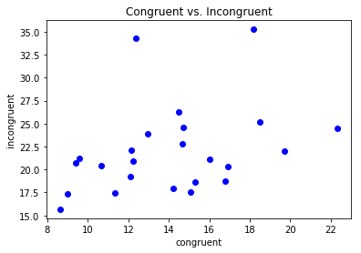

```python
plt.scatter(df.Congruent, df.Incongruent, color = 'blue')
plt.title('Congruent vs. Incongruent')
plt.xlabel('congruent')
plt.ylabel('incongruent')
plt.show()
```

Congruent and Incongruent has a weak linear relationship.

(5) Now, perform the statistical test and report the results. What is the confidence level and your critical statistic value? Do you reject the null hypothesis or fail to reject it? Come to a conclusion in terms of the experiment task. Did the results match up with your expectations?

```python
d1 = sm.stats.DescrStatsW(df.Congruent)
d2 = sm.stats.DescrStatsW(df.Incongruent)

compare_means = sm.stats.CompareMeans(d1, d2)
compare_means.ztest_ind(alternative="larger")
```

```
(-6.5322505539032303, 0.99999999996760569)
```